# Creating the Best Team Strength Proxy

Austin Stephen

7/22/2021

## Two Approachs to Building a Proxy for Team Strength

The baseline unconstrained model uses the rolling win percentage difference between teams and their average rating difference for the end of the season. This model explains 14.43 percent of the variance in the response. We achieve a **28 percent improvement** over this model.

### Model Details:

### Hyperparameter tunning for the window size:

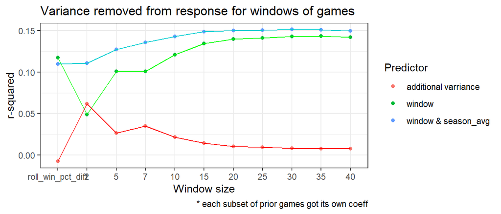

### Temporal Weighting:

Larger windows can be improved by allowing them to assign different weights to depending on how close the current game of interest.

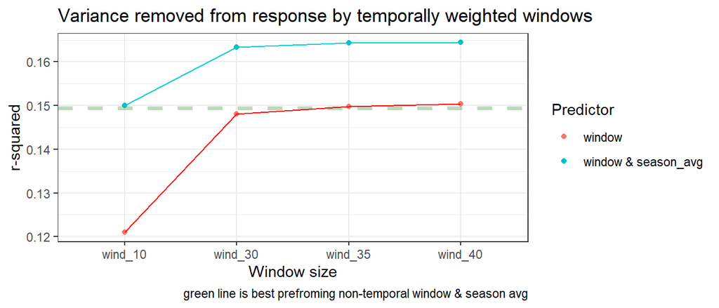

Now the benefit of larger windows stops at a size of 40 instead of 30. It also explains an additional 1.5 percent of the variance in the response.

#### Inside the model

It is fair to ask if the model is actually assigning the temporal weights in the way I asserted would add predictive value. The coefficients here show how relevant a window of time is to the game outcome.

```r
# Coefficients:
#                    Estimate Std. Error t value Pr(>|t|)
# (Intercept)       -3.600e-16  9.095e-02   0.000  1.00000
# wind_1_5          3.399e-02  1.976e-03  17.203  < 2e-16 ***
# wind_6_10         2.587e-02  2.082e-03  12.423  < 2e-16 ***
# wind_11_15        1.870e-02  2.173e-03   8.606  < 2e-16 ***
# wind_16_20        1.224e-02  2.273e-03   5.384 7.35e-08 ***
# wind_21_25        1.018e-02  2.360e-03   4.316 1.60e-05 ***
# wind_26_30        1.147e-02  2.481e-03   4.623 3.80e-06 ***
# wind_31_35        9.338e-03  2.589e-03   3.607  0.00031 ***
# wind_36_40        5.312e-03  2.634e-03   2.017  0.04376 *
# net_rating_diff   2.763e-01  1.548e-02  17.849  < 2e-16 ***
# ---
```

The regression is in general doing what we expect by weighting more recent games more heavily since they are contributing more information about the current state of the team.

### Decreasing relevance of the season average as observations increase:

As the season progresses we get more observations of the team, so we want to shift importance off the final season net rating onto the rolling weighted window. For example, when we have only seen the team play once or twice we want the season average rating to make up almost all of the prediction. However, once we have the weighted average of the past 40 games the season average should no longer make up nearly all of the prediction. A simple linear model has fixed coefficients that cannot change in this way. So I made an interaction with the number games the team has played in the season so the model would make this tradeoff. This improved the performance of the model to an adjusted r-squared of 0.1654.

Again looking inside the model we can see it is behaving exactly as expected as the season goes on the importance of the season average is decreased.

```r
# Coefficients:
#                               Estimate Std. Error t value Pr(>|t|)
# (Intercept)                  -2.807921   0.251202 -11.178  < 2e-16 ***
# wind_5                        0.034744   0.002723  12.757  < 2e-16 ***
# wind_10_hollow_5              0.024875   0.002868   8.672  < 2e-16 ***
# wind_15_hollow                0.019363   0.002994   6.467 1.05e-10 ***
# wind_20_hollow                0.014574   0.003137   4.646 3.43e-06 ***
# wind_25_hollow                0.009554   0.003265   2.927 0.003435 **
# wind_30_hollow                0.012856   0.003438   3.739 0.000186 ***
# wind_35_hollow                0.012233   0.003603   3.395 0.000689 ***
# wind_40_hollow                0.008635   0.003689   2.341 0.019257 *
# net_rating_diff               0.380649   0.036473  10.436  < 2e-16 ***
# games_played                 -0.001283   0.005654  -0.227 0.820548
# net_rating_diff:games_played -0.003210   0.000870  -3.690 0.000226 ***
```

### Unconstrained Centered Window:

Now we are expanding model by using all of the previous techniques but also using the outcomes of future games to get a more accurate picture of how good the team is at the current point in time.

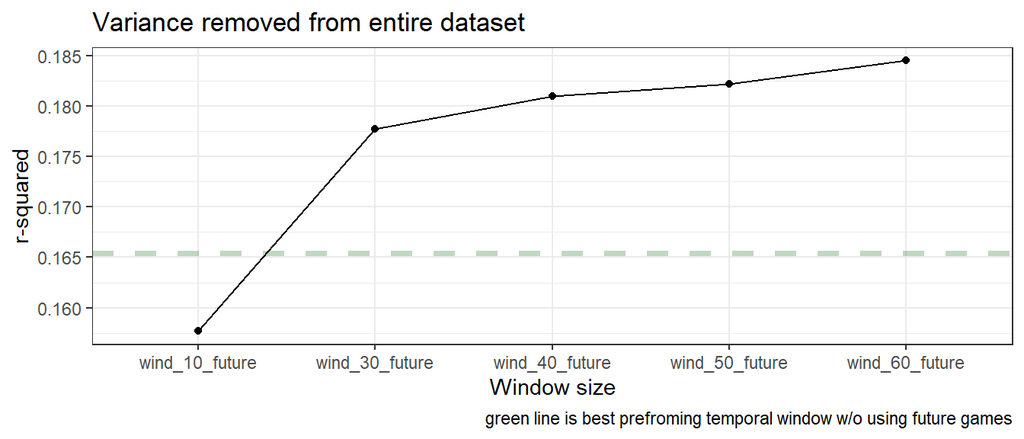

This allowed us to explain a little less than 2 percent additional variance in the response.

### 10-fold cross validation:

With a more complex model for team strength we needed to ensure we were not just overfitting to the data. The 60 game centered window was the best in 10-fold cross validation and will give us the best proxy for team strength.

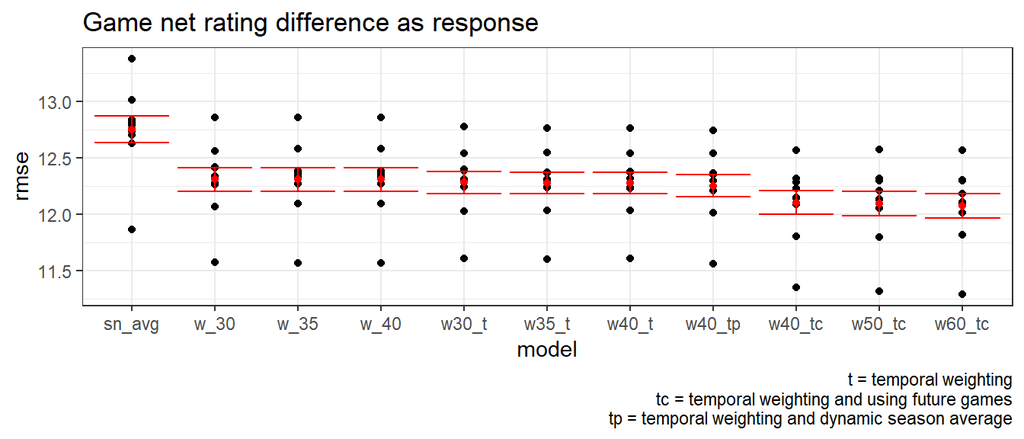